# Reproducible Research: Peer Assessment 1

## Loading and preprocessing the data

Here we load the data from disk. We also set some basic options to control how numbers are printed.

```r
# Set options to NOT print numbers as scientific notation and use only 3 decimal points
options("scipen" = 1)
options("digits" = 3)

# Read the data from disk into a Data Frame
stepdata <- read.csv("activity.csv")
```

## What is mean total number of steps taken per day?

Here we compute the mean total number of steps taken per day and present the results in a histogram. We also compute the overall mean and median number of steps taken.

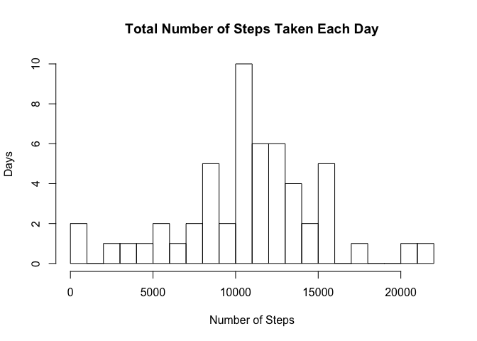

```r
##
##   Part 1 - Histogram of Total Number of Steps Taken Each Day + Mean and Median
##

# Split the data by date to make it easier to work with
daydata <- split(stepdata, stepdata$date)

# Initialize some vectors
sum_step_vector <- as.vector(NULL)
mean_step_vector <- as.vector(NULL)

# Iterate across all of the dates, computing the sum and a mean values for
#  the number of steps taken on each day.   Discard missing values.
for (day in levels(stepdata$date)) {
  steps_data_frame <- as.data.frame(daydata[day])
  steps_for_day <- steps_data_frame[,1]
  total_steps_for_day <- sum(steps_for_day, rm.na=TRUE)

  # accumulate total and mean vectors that can be used for plotting and subsequent computation
  sum_step_vector  <- c(sum_step_vector, total_steps_for_day)
  mean_step_vector <- c(mean_step_vector, mean(steps_for_day, rm.na=TRUE))
}

# plot the histogram showing the total number of steps taken on each day
hist(sum_step_vector, breaks=30, xlab="Number of Steps", ylab="Days", main="Total Number of Steps Taken Each Day")
```

The **mean** number of steps taken per day is computed as:

```r
mean_steps <- mean(sum_step_vector, na.rm=TRUE)
message(mean_steps)
```

```
## 10767.1886792453
```

The **median** number of steps taken per day is computed as:

```r
median_steps <- median(sum_step_vector, na.rm=TRUE)
message(median_steps)
```

```
## 10766
```

## What is the average daily activity pattern?

Here we analyze the daily activity pattern by summarizing the number of steps taken in each 5-minute interval across all days in our data. We construct a time series plot of the average number of steps taken in each of the 5-minute intervals across all days.

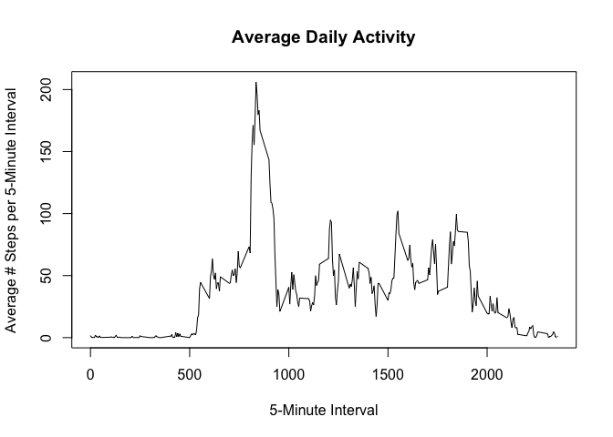

```r
######
######   Part 2 - Average Daily Activity Patterns
######

# Initialize some vectors
sum_interval_vector <- as.vector(NULL)
average_steps_per_interval <- as.vector(NULL)

# This time, we split the data by Interval (instead of date)
intervaldata <- split(stepdata, as.factor(stepdata$interval))

# Initialize some variables before entering the loop
max_interval_val = as.numeric(0)
max_interval_index = NA

# iterate across all interval levels to compute the mean activity level per
#   interval across all days
for (interval in levels(as.factor(stepdata$interval))) {
    steps_data_frame <- as.data.frame(intervaldata[interval])
    steps_for_interval <- steps_data_frame[,1]

    # compute the mean value for all steps in this interval and discaring missing values
    #  Also track the interval averages across all days that contains the maximum number steps
    val = mean(steps_for_interval,na.rm=TRUE)
    if(val > max_interval_val) {
      max_interval_val = val
      max_interval_index = interval
    }

    # accumulate a vector of all step averages per interval for later plotting
    average_steps_per_interval <- c(average_steps_per_interval, val)

}

# compute the overal average number of steps across all intervals
overall_average_interval <- mean(average_steps_per_interval, na.rm=TRUE)

# Create a time series plot showing the average steps per interval as averaged across all days
plot(levels(as.factor(stepdata$interval)), average_steps_per_interval, type="l", xlab="5-Minute Interval", ylab="Average # Steps per 5-Minute Interval", main="Average Daily Activity")
```

The 5-minute interval, averaged across all days in the dataset, that contains the maximum number of steps is 835. The maximum number of steps, averaged across all days, in this interval is 206.17.